# 实验四 非线性规划

目录

## 例题

### 【例题1】解非线性规划：

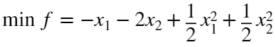

[figure not shown]

```matlab
func3 = @(x)-x(1)-2*x(2)+(1/2)*x(1)^2+(1/2)*x(2)^2;
x0 = [1; 1];
A = [2 3; 1 4];
b = [6; 5];
lb = zeros(2, 1);
[x, fval] = fmincon(func3, x0, A, b, [], [], lb, [])
```

Local minimum found that satisfies the constraints. Optimization completed because the objective function is non-decreasing in feasible directions, to within the value of the optimality tolerance, and constraints are satisfied to within the value of the constraint tolerance. <stopping criteria details>

x = 2×1

0.7647 1.0588

fval = -2.0294

### 【例题2】解非线性规划：

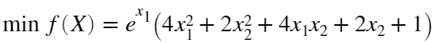

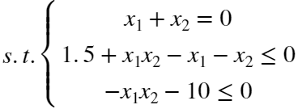

```matlab
func4 = @(x)exp(x(1))*(4*x(1)^2+2*x(2)^2+4*x(1)*x(2)+2*x(2)+1);
x0 = [-1; 1];
Aeq = [1 1];
beq = 0;
[x, fval] = fmincon(func4, x0, [], [], Aeq, beq, [], [], @mycon)
```

Local minimum found that satisfies the constraints. Optimization completed because the objective function is non-decreasing in feasible directions, to within the value of the optimality tolerance, and constraints are satisfied to within the value of the constraint tolerance. <stopping criteria details>

x = 2×1

-3.1623 3.1623

fval = 1.1566

### 【例题3】解非线性规划：

```matlab
fun = @(x)-2*x(1)-x(2);
x0 = [3; 2.5];
lb = [0; 0];
ub = [5; 10];
[x, fval, exitflag, ~] = fmincon(fun, x0, [], [], [], [], lb, ub, @mycon2)
```

Local minimum found that satisfies the constraints. Optimization completed because the objective function is non-decreasing in feasible directions, to within the value of the optimality tolerance, and constraints are satisfied to within the value of the constraint tolerance. <stopping criteria details>

x = 2×1

4.0000 3.0000

fval = -11.0000

exitflag = 1

## 习题

### 2. 炼油厂将A、B、C三种原油加工成甲、乙、丙三种汽油，一桶原油加工成一桶汽油的费用为4元，每天至多能加工汽油14000桶。原油的买入价、买入量、辛烷值、硫含量，及汽油的卖出价、需求量、辛烷值、硫含量由表给出。如何安排生产计划，使利润最大？

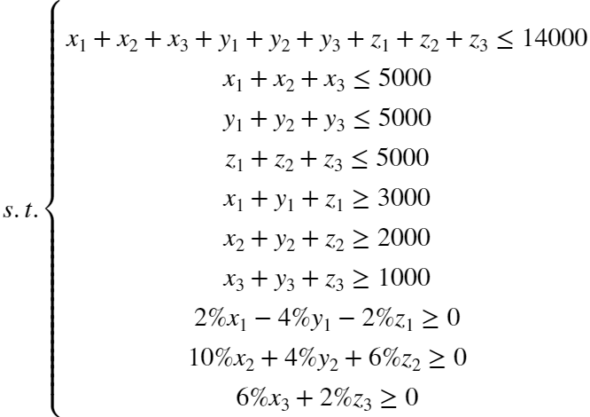

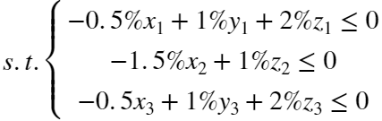

```matlab
f = [49 49 49 39 39 39 29 29 29];
A = [
    1 1 1 1 1 1 1 1 1;
    1 1 1 0 0 0 0 0 0;
    0 0 0 1 1 1 0 0 0;
    0 0 0 0 0 0 1 1 1;
    -1 0 0 -1 0 0 -1 0 0;
    0 -1 0 0 -1 0 0 -1 0;
    0 0 -1 0 0 -1 0 0 -1;
    -2 0 0 4 0 0 -2 0 0;
    0 -10 0 0 -4 0 0 -6 0;
    0 0 -6 0 0 0 0 0 -2;

    -0.5 0 0 1 0 0 2 0 0;
    0 -1.5 0 0 0 0 0 1 0;
    0 0 -0.5 0 0 1 0 0 2;
];
b = [
    14000; 5000; 5000; 5000; -3000; -2000; -1000; 0; 0; 0;
    0; 0; 0;
];
[x, fval] = intlinprog(f, 1 : 9,  A, b, [], [], zeros(9, 1));
```

LP: Optimal objective value is 254000.000000. Optimal solution found. Intlinprog stopped at the root node because the objective value is within a gap tolerance of the optimal value, options.AbsoluteGapTolerance = 0 (the default value). The intcon variables are integer within tolerance, options.IntegerTolerance = 1e-05 (the default value).

```matlab
x, (38000 - fval)
```

x = 9×1

10<sup>3</sup> ×

2.4000 0.8000 0.8000 0 0 0 0.6000 1.2000 0.2000

ans = -2.1600e+05

### 一般来说，做广告可以增加销售，估计一天向一种汽油投入一元广告费，可使该汽油日销量增加10桶，且每天最多投入广告费800元。问：如何安排生产和广告计划使利润最大？

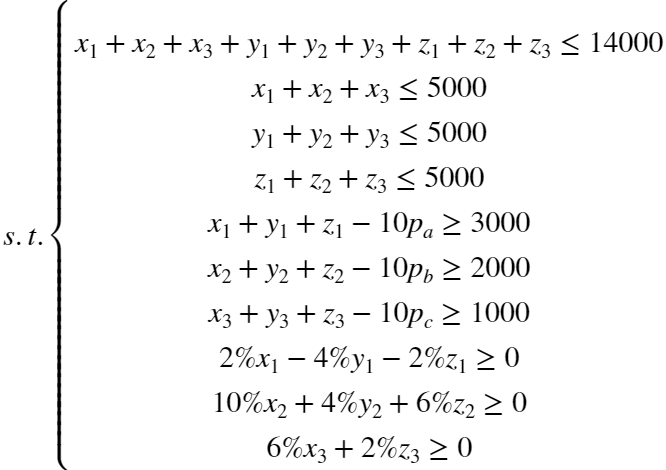

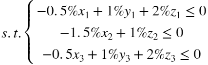

```matlab
f = [49 49 49 39 39 39 29 29 29 -699 -599 -499];
A = [
    1 1 1 1 1 1 1 1 1 0 0 0;
    1 1 1 0 0 0 0 0 0 0 0 0;
    0 0 0 1 1 1 0 0 0 0 0 0;
    0 0 0 0 0 0 1 1 1 0 0 0;
    -1 0 0 -1 0 0 -1 0 0 10 0 0;
    0 -1 0 0 -1 0 0 -1 0 0 10 0;
    0 0 -1 0 0 -1 0 0 -1 0 0 10;
    -2 0 0 4 0 0 -2 0 0 0 0 0;
    0 -10 0 0 -4 0 0 -6 0 0 0 0;
    0 0 -6 0 0 0 0 0 -2 0 0 0;

    -0.5 0 0 1 0 0 2 0 0 0 0 0;
    0 -1.5 0 0 0 0 0 1 0 0 0 0;
    0 0 -0.5 0 0 1 0 0 2 0 0 0;
];
b = [
    14000; 5000; 5000; 5000; -3000; -2000; -1000; 0; 0; 0;
    0; 0; 0;
];
[x, fval] = intlinprog(f, 1 : 12,  A, b, [], [], zeros(12, 1));
```

LP: Optimal objective value is 92250.000000. Optimal solution found. Intlinprog stopped at the root node because the objective value is within a gap tolerance of the optimal value, options.AbsoluteGapTolerance = 0 (the default value). The intcon variables are integer within tolerance, options.IntegerTolerance = 1e-05 (the default value).

```matlab
x, (38000 - fval)
```

x = 12×1 行 2:11

10<sup>3</sup> ×

2.2000 0.8000 1.0000 4.0000 0 0 3.3000 0.2000 0 0.7500

ans = -5.4250e+04

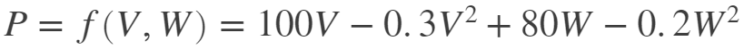

```matlab
% 记最优体积为x(1)，最优重量为x(2)
func = @(x)(100*x(1)-0.3*x(1)^2+80*x(2)-0.2*x(2)^2);
Aeq = [2 4;
    100 -80];
beq = [1040; 0];
[x, fval] = fmincon(func, zeros(2, 1), [], [], Aeq, beq, zeros(2, 1), [])
```

Local minimum possible. Constraints satisfied. fmincon stopped because the size of the current step is less than the value of the step size tolerance and constraints are satisfied to within the value of the constraint tolerance. <stopping criteria details>

x = 2×1

148.5714 185.7143

fval = 1.6194e+04

```matlab
% 记第k季度生产x(k)台设备
func = @(x)(58*x(1)+54*x(2)+50*x(3)+0.2.*sum(x.^2)-640);
A = [-1 0 0;
    -1 -1 0;
    -1 -1 -1];
b = [-40; -100; -180];
[x, fval] = fmincon(func, zeros(3, 1), A, b, [], [], [40; 0; 0], repmat(100, 3, 1))
```

Local minimum found that satisfies the constraints. Optimization completed because the objective function is non-decreasing in feasible directions, to within the value of the optimality tolerance, and constraints are satisfied to within the value of the constraint tolerance. <stopping criteria details>

x = 3×1

50.0000 60.0000 70.0000

fval = 1.1200e+04

### 5. 钢管下料问题。

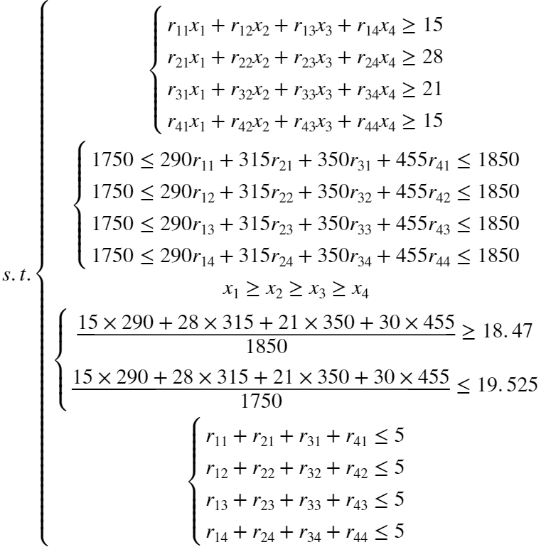

```matlab
%%%%% 这道题不会，所以没写 %%%%%
```

## 附录 本实验可能用到的函数

```matlab
function [c, ceq] = mycon(x)
%% 例题2的非线性限制
c = [1.5+x(1)*x(2)-x(1)-x(2); -x(1)*x(2)-10];
ceq = [];
end

function [c, ceq] = mycon2(x)
%% 例题3的非线性限制
c = [x(1)^2+x(2)^2-25; x(1)^2-x(2)^2-7];
ceq = [];
end
```